# W04 — Porównania grup i zależności kategorii

Zarządzanie informacją — część ilościowa — 2026/27

Marek Deja

2026/27

Wykład W04 porównuje dwie grupy, pary pomiarów, kilka grup i tabele kategorii. Skrypt `analiza.R` zapisany w folderze wykładu liczy małe syntetyczne demonstracje przygotowane dla wykładu, osobne względem zbioru S02; wyjątkiem jest wykres kwantylowy czasu S02. Kod skryptu pozostaje ukryty. Każda tabela podaje kierunek odejmowania, a każdy wykres ma w tekście słowny opis osi, wartości i wniosku.

# Jedna usługa, trzy projekty porównania

Biblioteka chce poprawić korzystanie z katalogu. Może porównać nowych i doświadczonych użytkowników, zaprosić te same osoby do zadania przed instruktażem i po nim albo losowo przydzielić dwie wersje pomocy. Każdy projekt dostarcza innej informacji: różnicy między istniejącymi grupami, zmiany wewnątrz osoby albo skutku przydzielonej wersji pomocy.

Istniejące grupy różnią się wieloma cechami. Projekt przed–po zachowuje osobę i łączy zmianę usługi z uczeniem się oraz upływem czasu. Losowy przydział warunku wzmacnia wniosek przyczynowy, gdy wykonanie badania respektuje założenia. Uogólnienie na wszystkich użytkowników wymaga w każdym z trzech projektów uzasadnionego doboru próby.

Wykład najpierw rozpoznaje jednostkę i strukturę danych, a potem opisuje różnicę średnich z testem Welcha, porównanie par i tabelę kategorii. Testy rangowe i porównania wielu grup służą czytaniu literatury. Ćwiczenie C06 (Dwie grupy: różnica czasu lub samooceny i tasowanie etykiet) używa testu Welcha i testu permutacyjnego, a ćwiczenie C07 (Kategorie i zachowanie: tabela, chi-kwadrat i Monte Carlo) — tabel 2×2.

# Projekt przed nazwą testu

Projekty porównania i ich jednostki

| Sytuacja | Jednostka i powiązanie | Przedmiot porównania |
| --- | --- | --- |
| Nowi i doświadczeni | Różne osoby w dwóch grupach | Średnie lub rozkłady wyników |
| Ta sama osoba przed i po | Para pomiarów jednej osoby | Zmiana wewnątrz osoby |
| Dwa warunki losowane | Osoby przydzielone według projektu | Wyniki między warunkami |
| Powodzenie w dwóch grupach | Jedna kategoria wyniku osoby | Proporcje lub struktura tabeli |
| Trzy wersje usługi | Trzy grupy albo trzy warunki tej samej osoby | Średnie trzech grup (ANOVA) albo trzech warunków tej samej osoby (pomiary powtarzane) |

Parę tworzy wspólna jednostka, np. ta sama osoba przed i po. Dziesięciu nowych i dziesięciu doświadczonych użytkowników tworzy dwie niezależne grupy także przy równej liczebności. Przy brakującym pomiarze analiza obejmuje kompletne pary.

Niezależność obserwacji wynika z projektu badania. Wiele prób tej samej osoby albo użytkownicy pracujący wspólnie tworzą obserwacje zależne; prosty wzór z N równym liczbie wierszy daje wtedy zbyt wąskie przedziały.

## Oznaczenia wykładu W04

Tabela „Oznaczenia wykładu W04” zbiera symbole wzorów wykładu; każdy symbol ma w tekście definicję w miejscu pierwszego użycia. Litery N i D w indeksie oznaczają grupy nowych i doświadczonych.

Oznaczenia wykładu W04

| Symbol | Znaczenie |
| --- | --- |
| $\Delta$, $\widehat\Delta$ | Różnica średnich w populacji i jej estymata, kierunek nowi minus doświadczeni |
| $\bar{x}_N$, $s_N$, $n_N$ | Średnia, SD i liczebność grupy nowych (analogicznie D) |
| $SE$, $t_W$, $\nu$ | Błąd standardowy różnicy, statystyka t Welcha, stopnie swobody Welcha (czytamy „ni”) |
| $s_p$, $d$, $g$ | Łączone SD (ang. *pooled*), d Cohena, g Hedgesa |
| $d_i$, $\bar{d}$, $s_d$, $n_{\mathrm{par}}$ | Różnica pary $i$, średnia i SD różnic, liczba par |
| $D^*$, $\varepsilon_i$ | Statystyka po przestawieniu etykiet; znak $\pm1$ w zmianie znaków |
| $\theta$, $R_N$, $U$ | Prawdopodobieństwo przewagi, suma rang grupy N, statystyka Manna–Whitneya |
| $SS$, $MS$, $F$, $\eta^2$ | Suma kwadratów, średni kwadrat, statystyka F, udział sumy kwadratów |
| $n_{ij}$, $n_{i\cdot}$, $n_{\cdot j}$, $N$ | Liczebność komórki, suma wiersza, suma kolumny, liczebność całej tabeli |
| $O_{ij}$, $E_{ij}$, $\chi^2$, $V$ | Liczebność obserwowana i oczekiwana, statystyka chi-kwadrat, V Craméra |
| $\hat{p}_N$, $\hat{p}_D$, $\bar{p}$, RR, OR | Proporcje sukcesu w grupach i łącznie, iloraz proporcji, iloraz szans |

# Różnica średnich ma ustalony kierunek

W porównaniu nowych i doświadczonych przyjmujemy:

$$\Delta=\mu_N-\mu_D,\qquad
\widehat\Delta=\bar{x}_N-\bar{x}_D.$$

Litery N i D w indeksie nazywają grupy: nowi i doświadczeni; liczebności oznaczają $n_N$ i $n_D$. Dodatnia różnica czasu oznacza, że nowi potrzebowali przeciętnie więcej minut, a dodatnia różnica indeksu — wyższą deklarowaną ocenę. Sens znaku wynika ze zmiennej wynikowej.

Hipoteza zerowa standardowego porównania średnich to $H_0:\Delta=0$, a dwustronna alternatywa dopuszcza różnicę w obu kierunkach. Materiał sprawdza zgodność znaku estymaty, znaku statystyki t i położenia przedziału.

## Mały przykład czasu

Tabela „Dwie grupy po pięć osób” podaje czasy, średnie i SD: nowi mają czasy 8, 10, 12, 14 i 16 minut (średnia 12, SD 3,16), a doświadczeni 4, 6, 8, 10 i 12 minut (średnia 8, SD 3,16). Każda wartość dotyczy innej osoby.

Dwie grupy po pięć osób

| Grupa | N | Czasy [min] | Średnia [min] | SD [min] |
| --- | --- | --- | --- | --- |
| Nowi | 5 | 8, 10, 12, 14, 16 | 12,00 | 3,16 |
| Doświadczeni | 5 | 4, 6, 8, 10, 12 | 8,00 | 3,16 |

Wykres „Czasy w dwóch niezależnych grupach” ma na osi poziomej czas w minutach i dwa wiersze punktów. Koła oznaczają osoby, romb średnią grupy, a pionowa kreska medianę.

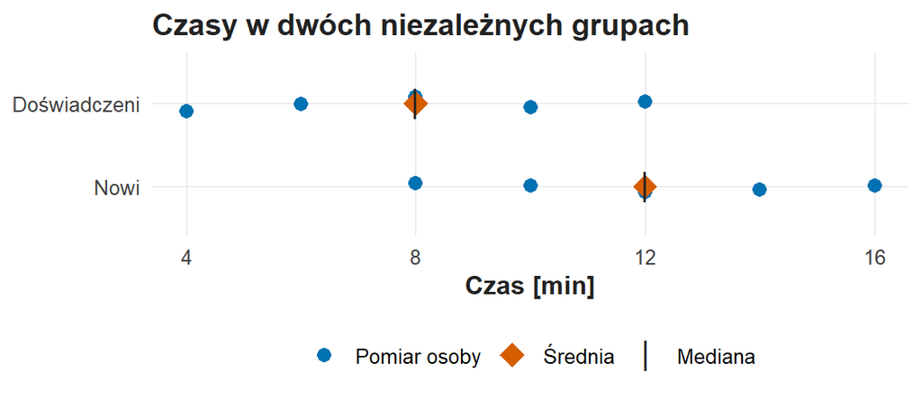

Czasy w dwóch niezależnych grupach. Oś pozioma: czas w minutach; dwa wiersze: nowi (8, 10, 12, 14, 16) i doświadczeni (4, 6, 8, 10, 12). Wartości 8, 10 i 12 minut występują w obu wierszach, a cały zestaw nowych leży 4 minuty dalej w prawo; romb i kreska mediany leżą przy 12 minutach u nowych i przy 8 minutach u doświadczonych.

Czasy 8, 10 i 12 minut występują w obu grupach. Różnica średnich opisuje grupy, a porównanie osób opisuje miara θ (definicja w części o rangach): losowo wybrany nowy użytkownik ma dłuższy czas od losowo wybranego doświadczonego z prawdopodobieństwem 0,82. Kwalifikacja do pomocy według długości próby obejmuje osoby z obu grup: czas 12 minut ma jedna osoba nowa i jedna doświadczona.

# Test Welcha: niepewność z obu grup

$$SE(\widehat\Delta)=
\sqrt{\frac{s_N^2}{n_N}+\frac{s_D^2}{n_D}},
\qquad
t_W=\frac{\widehat\Delta-0}{SE(\widehat\Delta)}.$$

Ćwiczenie C05 (Niepewność estymaty) porównywało średnią ze znaną liczbą, a test Welcha porównuje dwie oszacowane średnie. Niepewności obu średnich w modelu niezależnych grup sumują się pod pierwiastkiem, więc większy rozrzut lub mniejsze $n$ w którejkolwiek grupie zwiększa SE różnicy. W przykładzie $SE=\sqrt{10/5+10/5}=2$ minuty i $t_W=4/2=2$.

Test Welcha dopuszcza różne wariancje grup i wymaga właściwej jednostki analizy, niezależności oraz uzasadnienia przybliżenia rozkładem t. Bardzo małe skośne próby z wpływowymi obserwacjami wymagają ostrożnej interpretacji. Stopnie swobody wyznacza przybliżenie Welcha–Satterthwaite’a:

$$\nu=
\frac{(s_N^2/n_N+s_D^2/n_D)^2}
{\dfrac{(s_N^2/n_N)^2}{n_N-1}+
\dfrac{(s_D^2/n_D)^2}{n_D-1}} .$$

Wzór daje zwykle liczbę niecałkowitą, bo przybliża rozkład statystyki z dwiema oszacowanymi wariancjami; R używa liczby ν bez zaokrąglenia. Przy równych SD i równych liczebnościach, jak w przykładzie, $\nu=(2+2)^2/(4/4+4/4)=8$.

## Przedział, t i p w jednej historii

Przedział różnicy ma postać $\widehat\Delta\pm t_{0{,}975;\,\nu}\,SE$. Tabela „Test Welcha: nowi minus doświadczeni” zawiera różnicę 4 minuty, SE 2, przedział [−0,61; 8,61], $t=2{,}00$, $\nu=8$, $p=0{,}0805$, łączone SD 3,16 i dwie miary standaryzowane: $d=1{,}26$ i $g=1{,}14$.

Test Welcha: nowi minus doświadczeni

| Wielkość | Wartość |
| --- | --- |
| Różnica nowi − doświadczeni [min] | 4,00 |
| SE różnicy [min] | 2,00 |
| 95% CI różnicy [min] | [−0,61; 8,61] |
| Statystyka t Welcha | 2,00 |
| Stopnie swobody ν | 8,00 |
| Wartość p (dwustronna) | 0,0805 |
| Łączone SD s_p [min] | 3,16 |
| d Cohena | 1,26 |
| g Hedgesa | 1,14 |

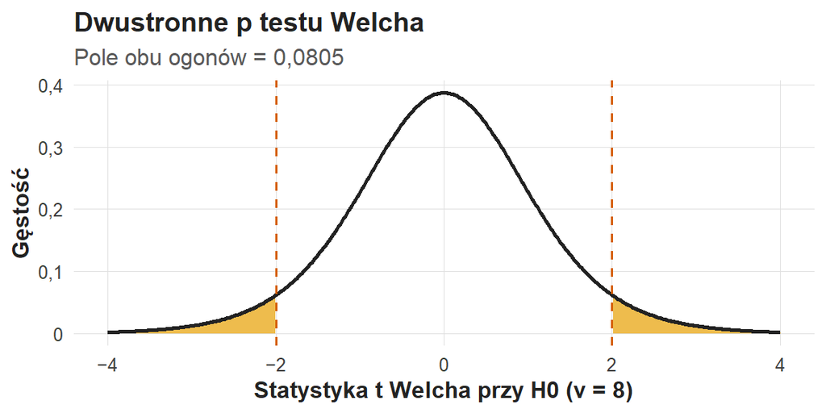

Dwustronne p testu Welcha. Oś pozioma: statystyka t przy H0 z 8 stopniami swobody; oś pionowa: gęstość. Krzywa jest symetryczna wokół zera; wyróżnione obszary na lewo od −2 i na prawo od 2 mają łączne pole 0,0805.

Różnica 4 minuty ma 95% CI [−0,61; 8,61]. Dane są zgodne z różnicami od −0,61 do 8,61 minuty: od niewielkiej przewagi nowych po wydłużenie ich czasu o ponad 8 minut. Wynik uzasadnia badanie z większą próbą: przy SD 3,16 minuty połowa szerokości przedziału 1 minuta wymaga około 77 osób w grupie.

## Wybór testu wynika z projektu i pytania

Test Shapiro–Wilka mierzy odchylenie od normalności, a jego moc rośnie z N: przy małym N wykrywa duże odchylenia, przy dużym także drobne. Ocenę rozkładu opiera się na wykresie kwantylowym i histogramie. Wykres kwantylowy zestawia uporządkowane wartości z kwantylami rozkładu normalnego standardowego; punkty wzdłuż prostej oznaczają zgodność z rozkładem normalnym.

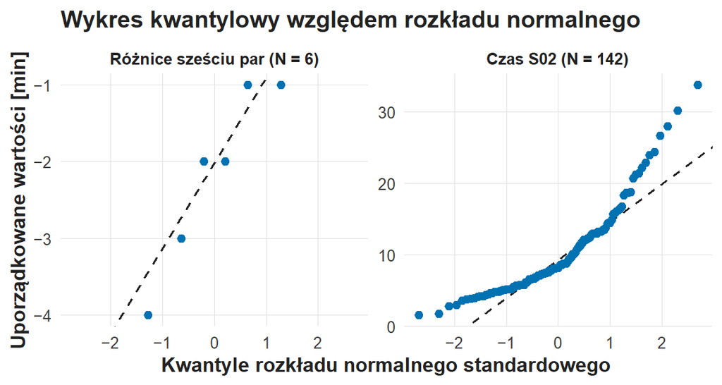

Wykres kwantylowy względem rozkładu normalnego. Oś pozioma: kwantyle rozkładu normalnego standardowego; oś pionowa: uporządkowane wartości w minutach; linia przerywana przechodzi przez kwartyle. Lewy panel: sześć różnic par (od −4 do −1 minuty) leży blisko linii. Prawy panel: 142 czasy S02 leżą blisko linii w środku, a na prawym końcu wznoszą się wyraźnie powyżej linii aż do 33,8 minuty, co oznacza prawy ogon.

Rdzeń kursu używa wersji Welcha dla każdego porównania dwóch średnich; ocena projektu, wykresów, braków i wpływowych obserwacji towarzyszy każdej analizie.

# Efekt standaryzowany i jego mianownik

Dla dwóch niezależnych grup różnicę dzieli się przez łączone SD:

$$s_p=\sqrt{\frac{(n_N-1)s_N^2+(n_D-1)s_D^2}{n_N+n_D-2}},
\qquad d=\frac{\widehat\Delta}{s_p}=\frac{4}{3{,}162}=1{,}26 .$$

Mianownikiem $g$ jest łączone SD osób (3,16 minuty), mianownikiem $t_W$ — SE różnicy (2 minuty). Dlatego $g$ opisuje wielkość względem rozrzutu osób, a $t_W$ — relację różnicy do niepewności jej oszacowania. Przy nierównych wariancjach opis nazywa sposób standaryzacji i podaje różnicę w minutach.

Standaryzowana różnica jest duża, a jej oszacowanie nieprecyzyjne: przedział różnicy obejmuje wartości od −0,61 do 8,61 minuty, a p przekracza 0,05. Różne mianowniki efektów dla projektów niezależnych i zależnych opisuje [Lakens (2013)](https://doi.org/10.3389/fpsyg.2013.00863); opis efektu podaje projekt i definicję miary.

# Test permutacyjny: tasowanie etykiet grup

Test permutacyjny (tasowanie etykiet) łączy wyniki obu grup, przypisuje etykiety grup na nowo z zachowaniem liczebności i ponownie liczy różnicę średnich. Dla dziesięciu czasów i dwóch grup po pięć istnieje $\binom{10}{5}=252$ podziałów, więc rozkład zerowy daje się wyliczyć w całości:

$$D^*=\bar{x}^*_N-\bar{x}^*_D,\qquad p=\frac{\#\{|D^*|\ge|D_{\mathrm{obs}}|\}}{252}=\frac{32}{252}=0,127 .$$

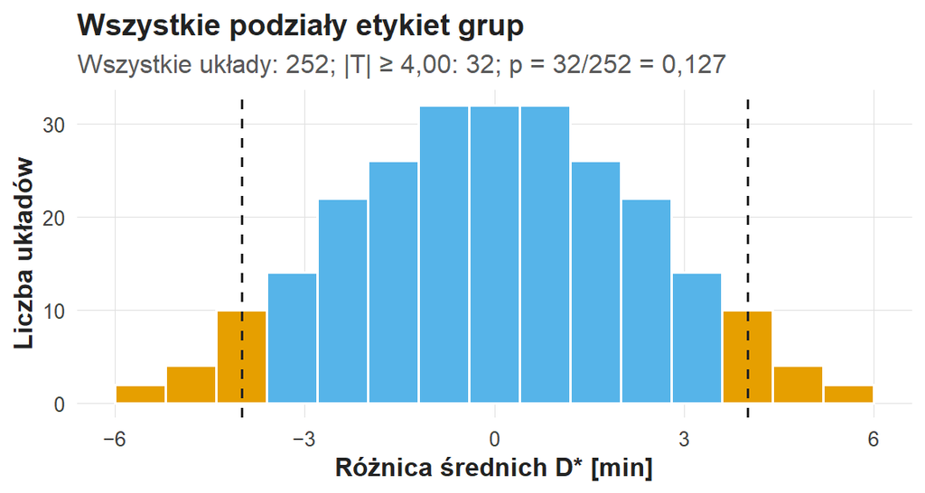

Wszystkie 252 podziały etykiet grup. Oś pozioma: różnica średnich D* w minutach; oś pionowa: liczba podziałów. Rozkład jest symetryczny wokół zera i leży od −5,6 do 5,6 minuty; linie przerywane przy −4 i 4 oznaczają obserwowaną różnicę i jej odbicie, a 32 podziały w wyróżnionych słupkach leżą na tych wartościach lub dalej.

Test permutacyjny daje $p=0{,}127$, a test Welcha $p=0{,}081$: dwie procedury opierają się na różnych rozkładach odniesienia, a przy pięciu osobach w grupie rozkład permutacyjny ma tylko 252 wartości. Uzasadnieniem przestawień jest wymienialność: przy $H_0$ każdy podział etykiet jest równie prawdopodobny. Wymienialność wymaga wspólnego rozkładu grup przy $H_0$; przy różnych wariancjach i nierównych liczebnościach tasowanie surowej różnicy średnich zmienia poziom $\alpha$, a statystyka $t_W$ jako miara skrajności (studentyzowany test permutacyjny) zachowuje poziom w przybliżeniu.

W grupach obserwacyjnych test permutacyjny sprawdza wymienialność etykiet; różnice wieku, zadań i wcześniejszego korzystania z usługi pozostają wyjaśnieniami alternatywnymi. Ćwiczenie C06 opisuje tor permutacyjny razem z ograniczeniem wynikającym z grup obserwacyjnych. Bootstrap różnicy losuje osoby z powtórzeniami osobno w każdej grupie, zachowuje przynależność do grupy i przybliża niepewność różnicy.

# Te same osoby przed i po: analizujemy różnice

W drugim projekcie sześć osób (a–f) wykonuje zadanie przed instruktażem i po nim. Kierunek to „po minus przed”, więc liczba ujemna oznacza skrócenie. Parę definiuje osoba: identyfikator łączy czas przed i po, a N wynosi sześć par. Tabela „Sześć par przed i po” zawiera czas przed, po i różnicę każdej osoby.

Sześć par przed i po instruktażu

| Osoba | Przed [min] | Po [min] | Różnica po − przed [min] |
| --- | --- | --- | --- |
| a | 6 | 5 | -1 |
| b | 8 | 6 | -2 |
| c | 10 | 9 | -1 |
| d | 12 | 9 | -3 |
| e | 14 | 12 | -2 |
| f | 16 | 12 | -4 |

Różnice wynoszą −1, −2, −1, −3, −2 i −4 minuty, a pytanie dotyczy ich średniej. Poziomy osób różnią się od 6 do 16 minut; sparowanie porównuje każdą osobę z nią samą.

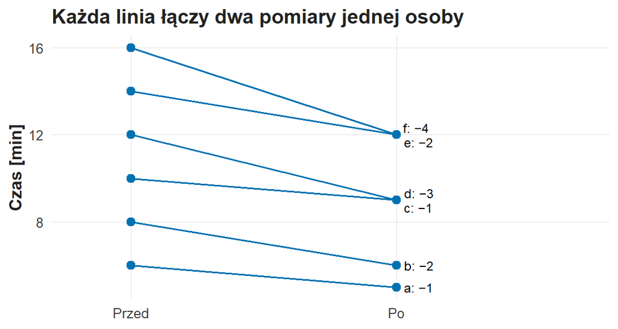

Każda linia łączy dwa pomiary jednej osoby. Oś pozioma: pomiar przed i po; oś pionowa: czas w minutach. Sześć odcinków z etykietami a–f; wszystkie opadają, o 1 minutę (a, c), 2 minuty (b, e), 3 minuty (d) i 4 minuty (f).

Test t dla par jest testem jednej średniej różnic:

$$d_i=x_{i,\mathrm{po}}-x_{i,\mathrm{przed}},
\qquad
t=\frac{\bar d}{s_d/\sqrt{n_{\mathrm{par}}}}.$$

Warunek normalności dotyczy rozkładu różnic $d_i$, a różnice osób są niezależne. Przy brakach analizę tworzą kompletne pary, a raport podaje ich liczbę. Sparowanie zmniejsza SE, bo SD różnic zależy od korelacji pomiarów tej samej osoby:

$$s_d^2=s^2_{\mathrm{przed}}+s^2_{\mathrm{po}}-2\,r\,s_{\mathrm{przed}}\,s_{\mathrm{po}},$$

gdzie $r$ to korelacja czasów przed i po. Przy $s_{\mathrm{przed}}=3,74$, $s_{\mathrm{po}}=2,93$ i $r=0,97$ otrzymujemy $s_d=1,17$ minuty; SD dwunastu czasów połączonych w jedną kolumnę wynosi 3,40 minuty. Tabela „Test t dla par” podaje wynik w minutach zmiany.

Test t dla par: po minus przed

| Wielkość | Wartość |
| --- | --- |
| Liczba par | 6 |
| Średnia zmiana po − przed [min] | −2,17 |
| SD różnic [min] | 1,17 |
| 95% CI zmiany [min] | [−3,39; −0,94] |
| Statystyka t | −4,54 |
| Stopnie swobody | 5 |
| Wartość p (dwustronna) | 0,0062 |

Zmiana −2,17 minuty, 95% CI [−3,39; −0,94], $t(5)=-4{,}54$, $p=0{,}0062$, łączy trzy mechanizmy: działanie instruktażu, zapamiętanie zadania i oswojenie z procedurą. Projekt z grupą kontrolną lub losową kolejnością warunków rozdziela trzy mechanizmy.

Test zmian znaków dla par zmienia znak różnicy wewnątrz osoby. Sześć par daje $2^6=64$ układy znaków:

$$\bar{d}^*=\frac{1}{6}\sum_{i=1}^{6}\varepsilon_i d_i,\qquad p=\frac{2}{64}=0,031 .$$

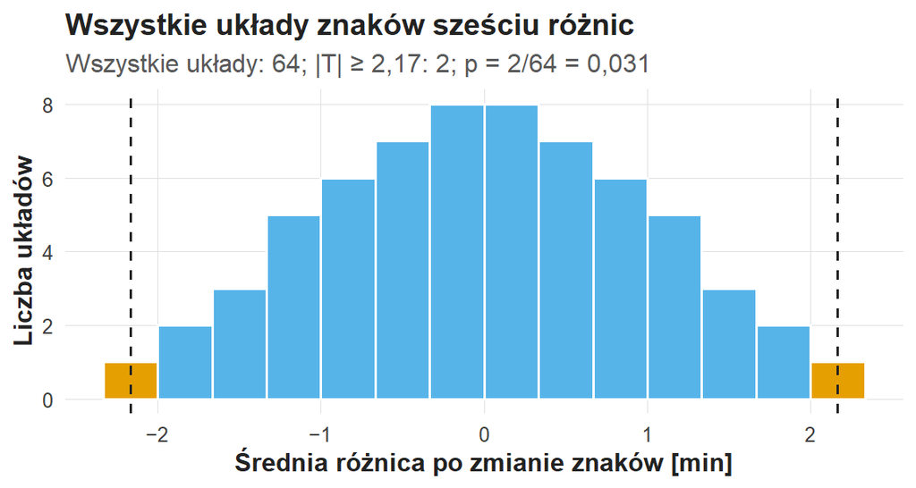

Wszystkie 64 układy znaków sześciu różnic. Oś pozioma: średnia różnica po zmianie znaków w minutach; oś pionowa: liczba układów. Rozkład jest symetryczny wokół zera i leży od −2,17 do 2,17 minuty; linie przerywane przy ±2,17 oznaczają obserwowaną średnią i jej odbicie, a dwa wyróżnione skrajne słupki zawierają po jednym układzie.

Dwa z 64 układów osiągają wartość ±2,17: wszystkie znaki ujemne (obserwowany układ) i wszystkie dodatnie. Wartość $p=2/64=0{,}031$ jest najmniejszą osiągalną przy sześciu parach, więc rozdzielczość testu ogranicza liczba par; test t daje $p=0{,}0062$ dzięki założeniu rozkładu t.

# Rangi: porządek wyników i miara θ

Test sumy rang Wilcoxona, nazywany też testem Manna–Whitneya, opiera się na położeniu obserwacji w uporządkowanym wspólnym zbiorze obu grup. Wartościom równym przypisuje się średnią ich rang. Miara probabilistyczna θ opisuje przewagę jednej grupy nad drugą:

$$\theta=P(X_N>X_D)+\tfrac12P(X_N=X_D),\qquad U=R_N-\frac{n_N(n_N+1)}{2},\qquad \hat\theta=\frac{U}{n_N\,n_D},$$

gdzie $R_N$ to suma rang grupy nowych. Dla czasu „wyższy” oznacza „dłuższy”. Wykres „25 par nowy–doświadczony” zestawia każdego nowego użytkownika z każdym doświadczonym.

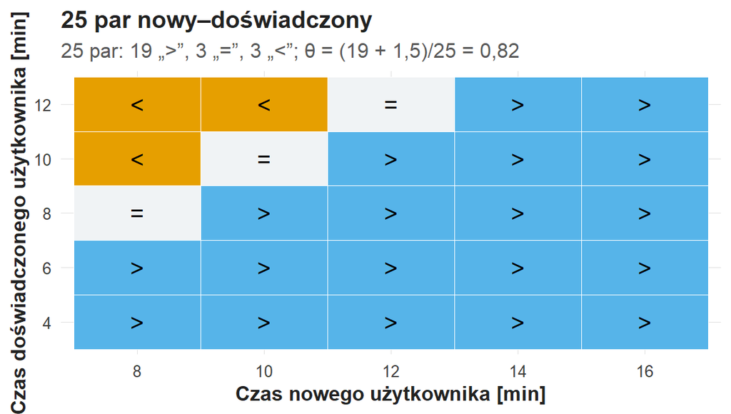

25 par nowy–doświadczony. Oś pozioma: czas nowego użytkownika (8–16 minut); oś pionowa: czas doświadczonego (4–12 minut). Każda komórka zawiera znak porównania: 19 komórek „>” (nowy dłużej), 3 komórki „=” (remis przy 8, 10 i 12 minutach) i 3 komórki „<” (doświadczony dłużej, w lewym górnym rogu); θ = (19 + 1,5)/25 = 0,82.

W przykładzie $\hat\theta=(19+1{,}5)/25=0{,}82$; w konwencji R statystyka wynosi $W=U=20{,}5$, a test z przybliżeniem normalnym daje $p=0,114$. Wartość θ = 0,5 oznacza równowagę porządku dwóch grup; rozkłady z θ = 0,5 mogą różnić się rozrzutem. Test Manna–Whitneya sprawdza hipotezę θ = 0,5, a odczyt wyniku jako przesunięcia mediany wymaga rozkładów o tym samym kształcie.

W teście rang podpisanych dla par wykorzystuje się znaki i rangi bezwzględnych różnic; odczyt wyniku jako przesunięcia zakłada symetrię rozkładu różnic. Szczegóły i definicje estymowanych wielkości podaje [dokumentacja wilcox.test](https://stat.ethz.ch/R-manual/R-devel/library/stats/html/wilcox.test.html).

## Pytanie wyznacza estymandę

Planowanie przeciętnego nakładu minut na obsługę wymaga średniej. Porównanie uporządkowania odpowiedzi porządkowych odpowiada pytaniu o θ. Wybór między średnią a rangami wynika z pytania; skośność wpływa na jakość przybliżenia.

Analiza dodatkowa nazywa swoją estymandę: test Welcha dotyczy różnicy średnich, test Manna–Whitneya — miary θ. Zgodne kierunki dwóch wyników opisują dwie estymandy.

# Wiele grup: analiza wariancji

Trzy wersje katalogu wymagają porównania trzech średnich. W jednoczynnikowej analizie wariancji (ANOVA) hipoteza zerowa mówi o równości wszystkich średnich, a alternatywa — że co najmniej dwie średnie się różnią. Wskazanie pary wymaga kontrastów lub porównań par z kontrolą wielokrotności.

Suma kwadratów dzieli się na część między grupami i część wewnątrz grup, a średni kwadrat to suma kwadratów podzielona przez jej stopnie swobody:

$$SS_{\mathrm{między}}=\sum_{g}n_g(\bar{x}_g-\bar{x})^2,\qquad
SS_{\mathrm{wewn}}=\sum_{g}\sum_{i}(x_{gi}-\bar{x}_g)^2,\qquad
MS=\frac{SS}{df},\qquad
F=\frac{MS_{\mathrm{między}}}{MS_{\mathrm{wewn}}} .$$

W demonstracji trzy grupy mają czasy A: 4, 5, 6; B: 7, 8, 9; C: 4, 6, 8 minut. Średnie grup wynoszą 5, 8 i 6 minut, a średnia ogólna 6,33 minuty; rachunek na dziewięciu osobach ilustruje wzory.

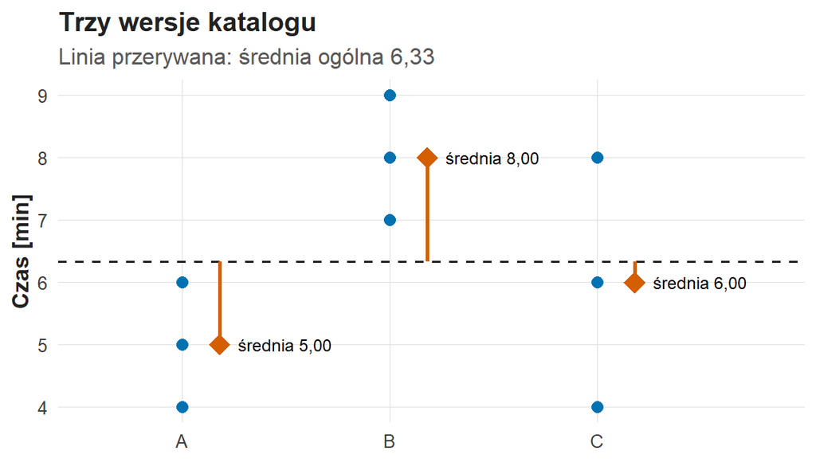

Trzy wersje katalogu. Oś pozioma: wersja A, B, C; oś pionowa: czas w minutach. Koła to czasy osób: A 4, 5, 6; B 7, 8, 9; C 4, 6, 8. Romby oznaczają średnie grup 5, 8 i 6 minut, linia przerywana średnią ogólną 6,33 minuty, a pionowe odcinki odległość średniej grupy od średniej ogólnej: 1,33 w dół dla A, 1,67 w górę dla B i 0,33 w dół dla C.

$SS_{\mathrm{między}}=3[(5-6{,}\overline{3})^2+(8-6{,}\overline{3})^2+(6-6{,}\overline{3})^2]=14$, a $SS_{\mathrm{wewn}}=2+2+8=12$. Tabela „Analiza wariancji trzech grup” podaje $MS$ równe 7 i 2 oraz $F=7/2=3{,}5$ przy stopniach swobody 2 i 6.

Analiza wariancji trzech grup

| Źródło | SS | df | MS | F | p |
| --- | --- | --- | --- | --- | --- |
| Między grupami | 14 | 2 | 7 | 3,50 | 0,0983 |
| Wewnątrz grup | 12 | 6 | 2 |  |  |
| Całkowita | 26 | 8 |  |  |  |

F jest liczbą bez jednostki: stosunkiem dwóch średnich kwadratów. Przy $H_0$ statystyka ma rozkład $F(k-1,\,N-k)$, tu $F(2,\,6)$, a wartość krytyczna $F_{0{,}95;\,2,\,6}=5{,}14$. Obserwowane 3,5 leży poniżej wartości krytycznej, a pole prawego ogona wynosi 0,098.

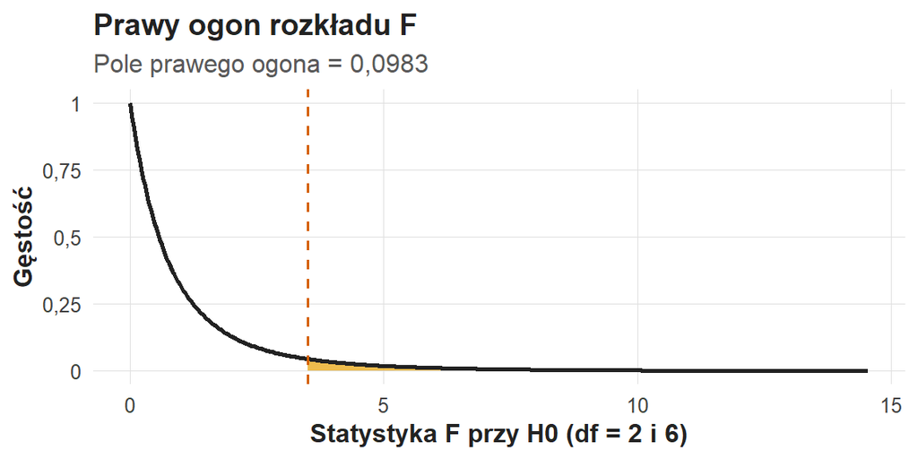

Prawy ogon rozkładu F z 2 i 6 stopniami swobody. Oś pozioma: statystyka F przy H0; oś pionowa: gęstość. Krzywa maleje od zera i ma długi prawy ogon; wyróżnione pole na prawo od linii przerywanej przy 3,5 wynosi 0,0983.

$\eta^2=SS_{\mathrm{między}}/SS_{\mathrm{całk}}=14/26=0{,}538$ oznacza, że 53,8% sumy kwadratów odchyleń od średniej ogólnej przypada na różnice między średnimi grup. Klasyczna ANOVA zakłada niezależność i wspólną wariancję błędów; wersja Welcha dopuszcza różne wariancje, a test Kruskala–Wallisa porównuje rozkłady rang trzech grup. Powtarzane pomiary tych samych osób wymagają modelu zachowującego bloki osób. Kontrasty zaplanowane przed analizą raportuje się niezależnie od wyniku testu ogólnego; porównania par wybrane po obejrzeniu wyników wymagają kontroli wielokrotności, np. poprawki Holma.

# Kategorie: najpierw tabela z liczebnościami

W osobnym przykładzie nowi mają 18 sukcesów na 30 osób, a doświadczeni 32 na 40. Jedna osoba wnosi jeden wynik w tabeli dwóch rozłącznych kategorii. Tabela „Sukces zadania w dwóch grupach” zawiera liczebności i sumy brzegowe: nowi — 18 sukcesów i 12 niepowodzeń (30 osób), doświadczeni — 32 i 8 (40 osób); łącznie 50 sukcesów i 20 niepowodzeń.

Sukces zadania w dwóch grupach (liczebności)

| Grupa | Sukces | Niepowodzenie | Suma |
| --- | --- | --- | --- |
| Nowi | 18 | 12 | 30 |
| Doświadczeni | 32 | 8 | 40 |
| Suma | 50 | 20 | 70 |

W pierwszej grupie sukces odnosi 60%, w drugiej 80%. Różnica −20 punktów procentowych jest różnicą bezwzględną; względnie odsetek nowych stanowi 75% odsetka doświadczonych ($0{,}60/0{,}80=0{,}75$).

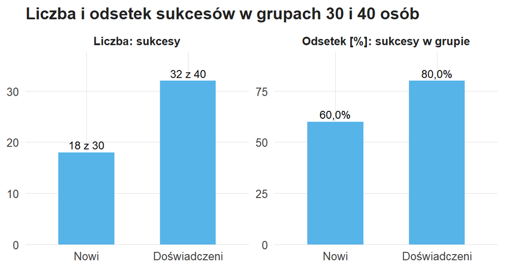

Liczba i odsetek sukcesów w grupach 30 i 40 osób. Lewy panel: liczba sukcesów — 18 z 30 nowych i 32 z 40 doświadczonych. Prawy panel: odsetek sukcesów w grupie — 60,0% nowych i 80,0% doświadczonych.

Udział nowych wśród wszystkich sukcesów, $18/50=36\%$, opisuje skład grupy sukcesów; skuteczność nowych opisuje odsetek $18/30=60\%$. Mianownik odpowiada zdaniu w raporcie.

# Chi-kwadrat: porównujemy O z E

Przy niezależności grupy i wyniku oczekiwana liczebność komórki wynosi:

$$E_{ij}=\frac{n_{i\cdot}\,n_{\cdot j}}{N}.$$

Kropka zastępuje sumowanie po drugim indeksie: $n_{1\cdot}$ to suma wiersza 1, a $n_{\cdot1}$ — suma kolumny 1. W pierwszej komórce $E_{11}=30\cdot50/70=21{,}43$ sukcesu nowych. Oczekiwana liczebność 21,43 jest wartością modelu niezależności i może być ułamkiem. Tabela „Liczebności oczekiwane przy niezależności” podaje: nowi 21,43 sukcesu i 8,57 niepowodzenia, doświadczeni 28,57 i 11,43; nowi mają 18 sukcesów, o 3,43 mniej od oczekiwanych.

Liczebności oczekiwane przy niezależności

| Grupa | Sukces | Niepowodzenie |
| --- | --- | --- |
| Nowi | 21,43 | 8,57 |
| Doświadczeni | 28,57 | 11,43 |

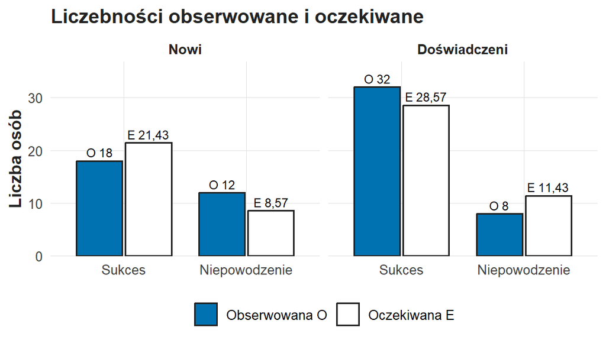

Liczebności obserwowane i oczekiwane. Dwa panele: nowi i doświadczeni; w każdym dwie komórki (sukces, niepowodzenie) z parą słupków: pełny obserwowany O i jasny oczekiwany E. Nowi: O 18 wobec E 21,43 sukcesu i O 12 wobec E 8,57 niepowodzenia. Doświadczeni: O 32 wobec E 28,57 i O 8 wobec E 11,43.

Statystyka chi-kwadrat sumuje wkłady komórek:

$$\chi^2=\sum_{i,j}\frac{(O_{ij}-E_{ij})^2}{E_{ij}}.$$

Kwadrat usuwa znak, a dzielenie przez $E_{ij}$ odnosi odchylenie do skali oczekiwanej komórki. Statystyka $\chi^2$ mierzy odległość tabeli od niezależności; kierunek odczytuje się z proporcji. Tabela „Wkłady komórek do χ²” podaje wkłady 0,549 i 1,371 (nowi) oraz 0,411 i 1,029 (doświadczeni), suma 3,36. Największe wkłady mają komórki niepowodzeń, bo ich oczekiwane liczebności są mniejsze.

Wkłady komórek do χ²

| Grupa | Sukces | Niepowodzenie |
| --- | --- | --- |
| Nowi | 0,549 | 1,371 |
| Doświadczeni | 0,411 | 1,029 |

Statystyka $\chi^2$ rośnie proporcjonalnie do $N$ przy stałych proporcjach, więc funkcja `chisq.test()` przyjmuje liczebności: tabela procentów (N = 200) daje $\chi^2=9{,}52$, a tabela liczebności (N = 70) — 3,36.

## Rozkład chi-kwadrat

Rozkład chi-kwadrat o $df$ stopniach swobody to rozkład sumy kwadratów $df$ niezależnych zmiennych o rozkładzie normalnym standardowym:

$$\chi^2_{df}=Z_1^2+\dots+Z_{df}^2,\qquad \chi^2_{0{,}95;\,1}=3{,}84=1{,}96^2 .$$

Dla tabeli $r$ na $c$ stopnie swobody wynoszą $(r-1)(c-1)$; w tabeli 2×2 jest to 1. Wykres „Rozkłady χ² o 1, 2 i 4 stopniach swobody” przedstawia trzy krzywe.

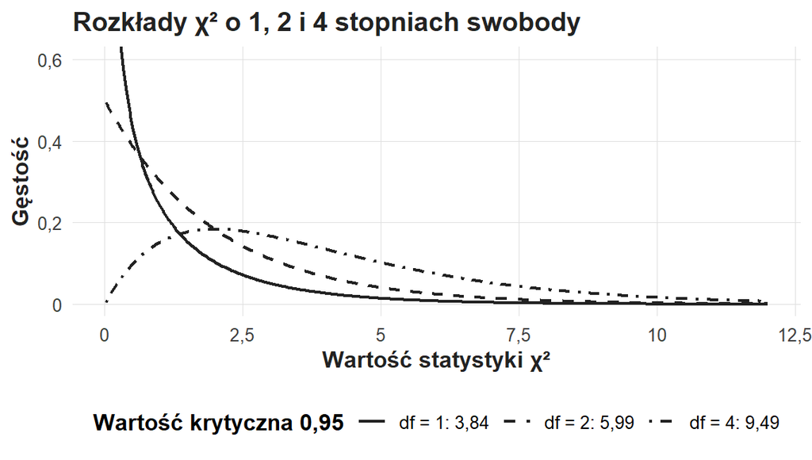

Rozkłady χ² o 1, 2 i 4 stopniach swobody. Oś pozioma: wartość statystyki χ² od 0 do 12; oś pionowa: gęstość. Wszystkie krzywe mają prawy ogon; krzywa dla df = 1 (ciągła) jest najwyższa przy zerze, krzywa dla df = 2 (przerywana) maleje od 0,5, a krzywa dla df = 4 (kropkowo-kreskowa) ma szczyt przy 2. Wartości krytyczne 0,95 wynoszą 3,84; 5,99 i 9,49.

Przybliżenie rozkładem $\chi^2$ wymaga dużych oczekiwanych liczebności; reguła praktyczna: każde $E_{ij}\ge5$. W przykładzie $\chi^2(1)=3{,}36$ leży poniżej wartości krytycznej 3,84, a $p=P(\chi^2_1\ge3{,}36)=0{,}067$.

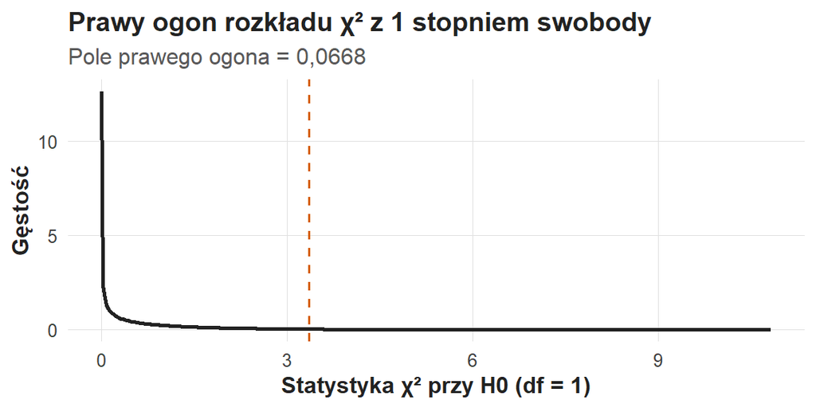

Prawy ogon rozkładu χ² z 1 stopniem swobody. Oś pozioma: statystyka χ² przy H0; oś pionowa: gęstość. Krzywa maleje od zera; wyróżnione pole na prawo od linii przerywanej przy 3,36 wynosi 0,0668.

Test dwóch proporcji łączy rozkład normalny z rozkładem $\chi^2$:

$$z=\frac{\hat{p}_N-\hat{p}_D}{\sqrt{\bar{p}(1-\bar{p})\left(\frac{1}{n_N}+\frac{1}{n_D}\right)}}=-1{,}833,\qquad z^2=3{,}36=\chi^2,\qquad \bar{p}=\frac{50}{70},$$

gdzie $\bar{p}$ to łączna proporcja sukcesu. W tabeli 2×2 test z i test $\chi^2$ bez korekty ciągłości dają tę samą wartość p.

# Fisher i Monte Carlo: inne rozkłady odniesienia

Test Fishera liczy p z rozkładu hipergeometrycznego przy ustalonych marginesach tabeli, więc działa przy małych liczebnościach; wymaga niezależnych jednostek i poprawnej tabeli. Rozkład hipergeometryczny podaje prawdopodobieństwo $k$ sukcesów w pierwszym wierszu:

$$P(n_{11}=k)=\frac{\binom{n_{1\cdot}}{k}\binom{n_{2\cdot}}{n_{\cdot1}-k}}{\binom{N}{n_{\cdot1}}} .$$

Wersja Monte Carlo testu niezależności losuje tabele o tych samych sumach wierszy i kolumn i porównuje ich statystykę $\chi^2$ z obserwowaną; schemat i rolę B określa [dokumentacja chisq.test](https://stat.ethz.ch/R-manual/R-devel/library/stats/html/chisq.test.html). Tabela „Trzy procedury dla tabeli 18/30 i 32/40” zestawia wyniki: $\chi^2=3{,}36$, df = 1, p = 0,0668 (bez korekty ciągłości); Monte Carlo p = 0,108 (B = 1999); Fisher p = 0,108.

Trzy procedury dla tabeli 18/30 i 32/40

| Procedura | Statystyka | Wartość p |
| --- | --- | --- |
| χ² bez korekty ciągłości | χ²(1) = 3,36 | 0,0668 |
| Monte Carlo (B = 1999, marginesy stałe) | χ² = 3,36 | 0,108 |
| Dokładny test Fishera | — | 0,108 |
| Test z dwóch proporcji | z = −1,833; z² = 3,36 | 0,0668 |

Przybliżenie $\chi^2$ daje mniejsze p niż dwie procedury warunkowe. Raport podaje metodę wybraną przed analizą i pozostałe wyniki jako analizę wrażliwości.

W tabeli rzadkiej pierwsza grupa ma 1 sukces na 10, druga 7 na 10. Tabela „Tabela rzadka” zawiera: nowi — 1 sukces i 9 niepowodzeń, doświadczeni — 7 i 3; łącznie 8 sukcesów i 12 niepowodzeń.

Tabela rzadka (liczebności)

| Grupa | Sukces | Niepowodzenie | Suma |
| --- | --- | --- | --- |
| Nowi | 1 | 9 | 10 |
| Doświadczeni | 7 | 3 | 10 |
| Suma | 8 | 12 | 20 |

Jakość przybliżenia ocenia się po liczebnościach oczekiwanych: oczekiwane liczebności sukcesów wynoszą po 4, poniżej progu 5. Przy marginesach 10, 10, 8 i 12 rozkład hipergeometryczny $n_{11}$ obejmuje wartości od 0 do 8.

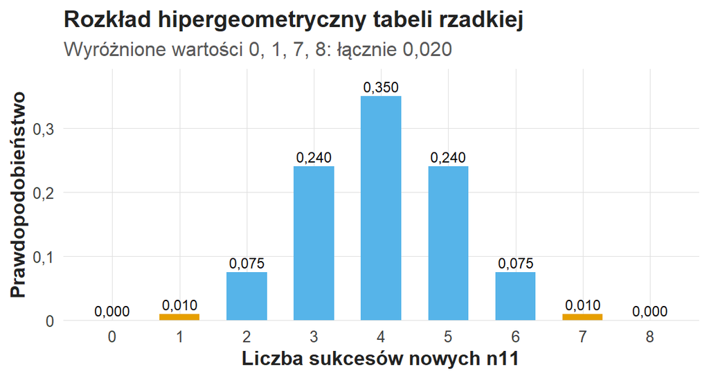

Rozkład hipergeometryczny tabeli rzadkiej: liczba sukcesów nowych n11 przy marginesach 10, 10, 8 i 12. Oś pozioma: n11 od 0 do 8; oś pionowa: prawdopodobieństwo. Słupki są symetryczne wokół 4 (0,350); wyróżnione słupki 0, 1, 7 i 8 mają prawdopodobieństwa 0,0004; 0,0095; 0,0095 i 0,0004, łącznie 0,020.

Słowo „dokładny” oznacza, że p wynika z pełnego rozkładu hipergeometrycznego; dwustronne p sumuje prawdopodobieństwa tabel o prawdopodobieństwie mniejszym lub równym obserwowanemu: $P(0)+P(1)+P(7)+P(8)=0{,}020$. Szczegóły podaje [dokumentacja fisher.test](https://stat.ethz.ch/R-manual/R-devel/library/stats/html/fisher.test.html).

# Wielkość związku: V oraz kierunkowe różnice

V Craméra ma postać:

$$V=\sqrt{\frac{\chi^2}{N\min(r-1,c-1)}}=\sqrt{\frac{3{,}36}{70}}=0{,}219 .$$

W tabeli 2×2 mianownik pod pierwiastkiem upraszcza się do N. V = 0,219 opisuje siłę związku na skali od 0 (niezależność) do 1 (pełna zależność); kierunek podaje różnica proporcji. Iloraz proporcji i iloraz szans zapisuje się z liczebnościami komórek:

$$RR=\frac{\hat{p}_N}{\hat{p}_D}=\frac{0{,}60}{0{,}80}=0{,}75,\qquad
OR=\frac{n_{11}/n_{12}}{n_{21}/n_{22}}=\frac{n_{11}n_{22}}{n_{12}n_{21}}=\frac{18\cdot8}{12\cdot32}=0{,}375 .$$

Tabela „Miary efektu dla tabeli 2×2” zachowuje kierunek nowi względem doświadczonych: różnica −0,20, 95% CI [−0,415; 0,015] (przybliżenie Walda bez korekty ciągłości), iloraz proporcji 0,75, iloraz szans 0,375, V = 0,219.

Miary efektu dla tabeli 2×2

| Miara | Wartość |
| --- | --- |
| Różnica proporcji nowi − doświadczeni | −0,20 |
| 95% CI różnicy (Wald) | [−0,415; 0,015] |
| Iloraz proporcji RR | 0,75 |
| Iloraz szans OR | 0,375 |
| V Craméra | 0,219 |

Szansa sukcesu to stosunek sukcesów do niepowodzeń: 1,5 u nowych (18/12) i 4 u doświadczonych (32/8). Przy częstym sukcesie iloraz szans (0,375) leży dalej od 1 niż iloraz proporcji (0,75). Wykres „Iloraz proporcji 0,75 a iloraz szans” przedstawia obie miary przy stałym ilorazie proporcji.

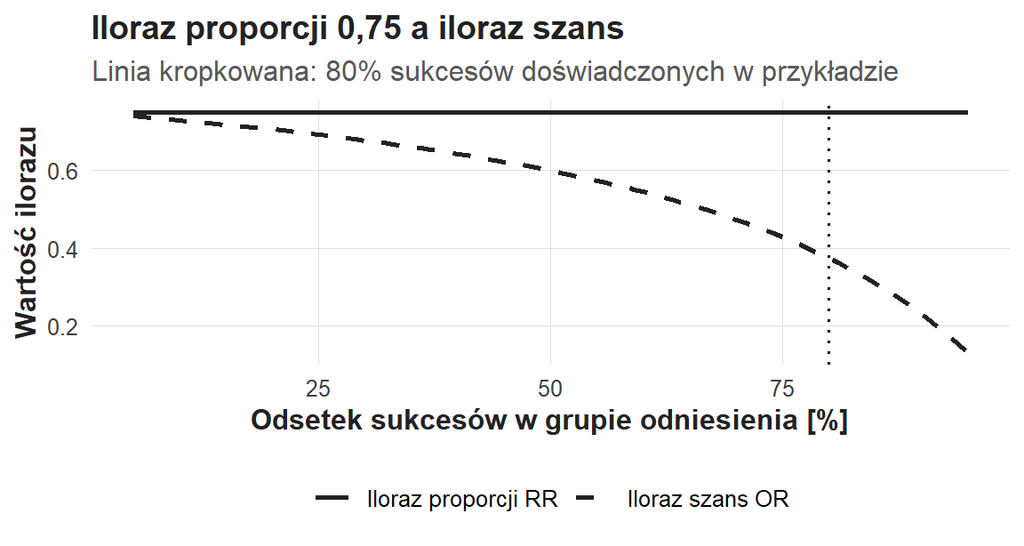

Iloraz proporcji 0,75 a iloraz szans. Oś pozioma: odsetek sukcesów w grupie odniesienia od 5 do 95%; oś pionowa: wartość ilorazu. Linia ciągła RR pozostaje przy 0,75; linia przerywana OR wynosi 0,74 przy 5% sukcesów i maleje coraz szybciej, do 0,375 przy 80% (linia kropkowana).

Przy rzadkim sukcesie obie miary są bliskie; przy odsetkach powyżej 50% iloraz szans oddala się od ilorazu proporcji, więc raport nazywa użytą miarę.

## Przedział bootstrapowy dla V

Prosty percentylowy przedział bootstrapowy V ma dodatnią dolną granicę także przy niezależności w populacji, bo V jest ograniczone od dołu zerem, a losowe próby odchylają się od dokładnej niezależności. Percentylowy przedział bootstrapowy V opisuje zmienność V; związek testuje się testem $\chi^2$, Fishera lub Monte Carlo. Ćwiczenie C07 przedstawia niepewność różnicy proporcji i osobno opisową miarę V.

# Cztery pytania do czytania artykułu LIS

Pierwszy artykuł podaje średni czas dwóch grup i pomija opis powiązań pomiarów. Mianownik statystyki t zależy od tego, czy grupy tworzą inne osoby, czy te same osoby w dwóch zadaniach, więc pierwsze pytanie brzmi: kogo porównano?

Drugi artykuł nazywa wynik testu rangowego różnicą średnich. Test rangowy dotyczy miary θ, więc drugie pytanie brzmi: jaką estymandę ma metoda i jak autor definiuje efekt?

Trzeci artykuł przedstawia $\chi^2$ i p bez tabeli. Kierunek i skalę różnicy skuteczności podają liczebności, proporcje i miara efektu, więc trzecie pytanie brzmi: jakie są liczebności komórek?

Czwarty artykuł pisze, że doświadczenie „wpływa” na skuteczność na podstawie grup obserwacyjnych. Wniosek przyczynowy wymaga projektu przyczynowego; poprawny opis związku jest pełnowartościowym wynikiem.

# Most do ćwiczeń C06 i C07

Ćwiczenie C06 porównuje dwie grupy z jednym ustalonym kierunkiem efektu, testem Welcha, przedziałami i testem permutacyjnym. Ćwiczenie C07 przechodzi od liczebności do proporcji, liczebności oczekiwanych, testu niezależności i efektu. Każde ćwiczenie zachowuje własne mianowniki i ograniczenia.

Pełne zdanie wyniku daje się sprawdzić w tabeli. Odpowiedź na problem biblioteki podaje wielkość, niepewność oraz grupy i warunki porównania.

# Literatura do dalszej pracy

- Lakens, D. (2013). *Calculating and reporting effect sizes to facilitate cumulative science: a practical primer for t-tests and ANOVAs*. Frontiers in Psychology, 4, 863. [DOI](https://doi.org/10.3389/fpsyg.2013.00863).
- Winkler, A.M., Ridgway, G.R., Webster, M.A., Smith, S.M., Nichols, T.E. (2014). *Permutation inference for the general linear model*. NeuroImage, 92, 381–397. [Pełny tekst](https://pmc.ncbi.nlm.nih.gov/articles/PMC4010955/).
- Dokumentacja R: [wilcox.test](https://stat.ethz.ch/R-manual/R-devel/library/stats/html/wilcox.test.html), [chisq.test](https://stat.ethz.ch/R-manual/R-devel/library/stats/html/chisq.test.html), [fisher.test](https://stat.ethz.ch/R-manual/R-devel/library/stats/html/fisher.test.html).

Przykłady liczbowe wykładu są dydaktyczne; wyniki cytowanych prac zawierają ich publikacje.